# Lab 050 · Q1 checkpoint

## FT-Transformer versus XGBoost under one protocol

Lesson · Quick reference

**Your skill:** construct a defensible comparison and keep your conclusion within its evidence. PROVIDED means readable implementation; TODO is your work; CHECK gives immediate diagnostics; EXIT combines output with your written claim audit.

**Scope:** full numeric FT-Transformer, XGBoost and MLP on three real OpenML tasks. This reviews an existing model, strengthens its implementation fidelity, and tests your protocol discipline. No categorical, regression or multiclass branch. A post-comparison three-model probability ensemble is a diagnostic exercise, not the paper Table 4 recipe. Local results are INCOMPARABLE to the paper benchmark. Required next step: a larger Higgs Small attempt with a printed ledger.

**Environment:** CPU sufficient for the learning lab (author run ~91 seconds; implementation and reading take longer). Colab bootstrap is the first code cell. PNG figures are embedded and need no execution. Author-reference snapshots are labeled; they are not your kernel output.

### Running on Google Colab?

Colab opens only this single file, so the course package (`relkit`) and the lab dependencies (xgboost, lightgbm, catboost, …) are **not** present by default. The cell below fixes that: on Colab it shallow-clones the course repo, installs `requirements-labs.txt`, and switches into `labs/` so `relkit` imports and the data cache resolve. **On a local venv or your own Jupyter it does nothing — just run it and continue.**

```python
# @colab-bootstrap — PROVIDED. Makes the lab self-sufficient on Google Colab; a no-op elsewhere.
import os, sys

if "google.colab" in sys.modules:
    if not os.path.isdir("/content/relational"):
        !git clone --depth 1 https://github.com/Avistian/relational.git /content/relational
    %pip install -q -r /content/relational/requirements-labs.txt
    os.chdir("/content/relational/labs")
    print("Colab ready — working dir:", os.getcwd())
else:
    print("Not on Colab — using the local environment as-is.")
```

## 1. Specify the decision before fitting anything

You have learned several ways to turn a row into a prediction: tree ensembles, ordinary neural layers, attention over features, attention across rows, and explicit products. The research question now changes from “how does this block work?” to “what evidence would justify choosing it?” For our relational-learning mission, this is a prerequisite: an apparent gain from relationships is not persuasive if the single-table alternative was weak or evaluated differently.

**In plain terms.** One dataset is one piece of evidence. Rerunning the same dataset with a new random seed tells you how stable your training is, but it does not give you a second dataset to generalize from. Count datasets, not runs.

The **experimental unit** is the object that supplies a distinct comparison. Here we compare model families within each dataset, so the dataset is the unit for the across-task rank summary. A random seed repeats training on that dataset; it does not create another dataset.

Our question is concrete: *under the declared numeric preprocessing and two-candidate validation search, how do a from-scratch FT-Transformer and XGBoost compare on diabetes, blood transfusion and phoneme?* An MLP supplies a simple neural baseline and a third arm for the Friedman procedure. These three real OpenML tasks are affordable substitutes, not the paper’s benchmark. Their selection favors small numeric binary problems. Neither categorical tables nor relational prediction is tested.

**Primary reading:** [Gorishniy et al., §4.5](https://arxiv.org/html/2106.11959v5#S4.SS5), then [Appendix D.2](https://arxiv.org/html/2106.11959v5#A4.SS2). The paper compares deep models in Table 2; its neural-versus-GBDT comparison in Table 4 uses ensembles. Here each seed produces one selected fitted model. Mean performance across seeds is not ensemble performance: an ensemble averages predictions first, then evaluates that combined predictor.

**Freeze this contract:** datasets and rows; target and positive class; split IDs; fit scope; metric; candidate lists; training caps; selection rule; seeds; uncertainty unit; and the language allowed in the conclusion. Changing these after reading test results creates a new exploratory experiment.

### The object being compared is a training procedure

“Transformer versus tree” sounds like a comparison between two functions. In an experiment it is a comparison between two procedures that produce functions. A procedure includes preprocessing, candidate configurations, initialization, training, checkpoint selection and prediction. Changing any of these can change the result even when the model's name stays the same.

Let D be the available training data and A the complete procedure. The fitted predictor is f=A(D). Our question is about the loss of that predictor on a specified population of future examples. This target of estimation is the **estimand**. For a random split, the intended population is usually exchangeable with the sampled table. For a temporal split, it is a later population. These are different estimands; an average of their scores has no automatic deployment meaning.

Write a decision sentence before opening the results: “On these datasets, under this split rule and this candidate budget, which procedure gives higher held-out AUROC?” That sentence is deliberately narrower than “Which architecture is best?” It tells a reader what your evidence could establish and what additional experiments would be needed for transfer.

Consider two apparently fair budgets. Giving each family ten configurations equalizes the number of validation comparisons. Giving each family one hour equalizes a resource constraint. They can produce different winners because configurations have different runtimes. Neither budget is universally correct. Choose the one that corresponds to the decision, record both realized time and candidate count, and explain the consequence.

The lab makes this concrete by saving the selected configuration and row identities with the scores. A naked AUROC value cannot tell you whether one method used extra validation feedback, fitted a transform on test features, or received a different target definition. The experimental artifact must identify the procedure that generated the number.

### Distinguish replication from a new trial

Repeating the same split with a different neural initialization measures one source of algorithmic variation. Drawing another split changes which observations are available for learning. Sampling another dataset changes the task. These repetitions answer different questions. Preserve their identities in the results table instead of flattening them into an undifferentiated list of runs.

If a method wins on three seeds of one dataset, it has shown repeatability on that dataset. It has not acquired three independent pieces of evidence about new datasets. This distinction becomes essential when you summarize the checkpoint across tasks.

```python
# PROVIDED — environment and data harness; no imported model is trained.
import os, sys, copy, hashlib, inspect, json, time
from pathlib import Path
import importlib.metadata
os.environ['OMP_NUM_THREADS']='1'
os.environ['OPENBLAS_NUM_THREADS']='1'
os.environ.setdefault('MPLCONFIGDIR','/tmp/relational-matplotlib')
import numpy as np
import pandas as pd
import torch
from torch import nn
from torch.nn import functional as F
from scipy.stats import t, rankdata, friedmanchisquare, studentized_range, binomtest
from sklearn.metrics import roc_auc_score, accuracy_score
from sklearn.model_selection import train_test_split
from xgboost import XGBClassifier
from threadpoolctl import threadpool_limits
thread_limit=threadpool_limits(limits=1)
torch.set_num_threads(1)
for candidate in (Path.cwd(),Path.cwd()/'labs',Path.cwd().parent):
    if (candidate/'relkit').is_dir():
        LABS=candidate.resolve();os.chdir(LABS);sys.path.insert(0,str(LABS));break
else: raise RuntimeError('Run from the repository root, labs/, or labs/solutions/.')
from relkit.data import load_tier_a, CACHE, SPECS
# The harness records the canonical source hash; EXIT adds live code identity.
__file__=str(LABS/'relkit/checkpoint.py')
print('Working directory:',LABS)
```

## 2. “Same protocol” is an information boundary

A model recommendation is a decision about future predictions. To evaluate that decision, first specify which information each candidate is allowed to use. “Same protocol” becomes concrete when every fit, choice and final score has an assigned partition.

**In plain terms.** Think of the three data splits as a wall. The training rows are allowed to teach the model and its preprocessing; the test rows are only allowed to grade it. If any fact from the test rows leaks backward across that wall, the grade is inflated — even when no label was touched.

Each split has one job. A **training set** estimates preprocessing parameters and model weights. A **validation set** selects candidates and stopping points. A **test set** measures the already selected procedure. Our split is stratified 60/20/20, using split seed 50 for both partition calls. Stratification approximately preserves class proportions. Exact row IDs are saved, so another reader need not infer the partition from its seed alone.

For numeric feature j, fit its median on training rows and use it to replace missing values. Then calculate the training mean μⱼ and population standard deviation σⱼ. Transform every partition using zⱼ=(xⱼ−μⱼ)/σⱼ; replace a zero σⱼ with one. An entirely missing training feature triggers an error requiring an explicit policy. The arrays have shape [B,C]: B rows and C numeric columns. The test set receives the transformation; it cannot estimate it.

**Worked example.** Training values [0,2] have mean 1, so centering the value 2 gives 1. Now add a held-out observation of 100. If you fit the mean on all three values you get 34, so that same training value of 2 becomes −32 instead of 1. Nothing about the training observations themselves changed; a held-out feature value silently changed their representation. No labels were necessary for this contamination. Its existence does not imply that every metric must improve.

**Predict:** move the held-out value to 200. Which mean is allowed to move?

The L046 verification harness used full-frame preprocessing before splitting. L050 does not reuse that data preparation. It also uses a different model implementation and different tasks; its scores must not be interpreted as a controlled before/after estimate of that earlier issue.

All three arms receive the same standardized numeric arrays. This keeps this checkpoint’s information and representation fixed. It is a disclosed choice, not a universal definition of fairness: a production comparison can legitimately allow each family its own training-only preprocessing. The paper uses neural quantile preprocessing and untransformed GBDT inputs ([Appendix B.2](https://arxiv.org/html/2106.11959v5#A2.SS2)).

### Follow one validation row through the pipeline

Suppose the training values of a numeric feature are 0 and 2. Their mean is 1. A validation value of 100 must be transformed using that training mean. If you first concatenate all three rows, the mean becomes 34, and information from the validation distribution has entered the fitted transform. No label was used, but the procedure has still changed from the declared inductive pipeline.

The rule is **fit on the training partition, transform every partition with the fitted state**. “Fit” includes estimating quantiles, imputing missing values, selecting features and building category vocabularies. It is not limited to gradient descent. A numerical transformer can have many learned preprocessing parameters before the first neural weight is updated.

For categorical columns, an unseen validation category must follow a policy chosen in advance: an unknown-category index, a hashing scheme, or another explicit treatment. Rebuilding the vocabulary on the full table makes the implementation convenient but obscures the prediction contract. Keep the vocabulary in the artifact so a future row is encoded the same way.

Fairness does not require forcing identical representations onto every family. Trees and transformers can have different sensible preprocessing. It requires comparable information access and an honest description of the recipes. If FT-T uses a training-fitted quantile transform while the tree uses raw numeric values, explain that these are family-specific procedures; do not pretend the only difference is an attention layer.

### Why the target transform belongs in the audit

For regression, standardizing targets changes the units of the optimization loss. A squared error of 0.2 in standardized space is not an RMSE of 0.2 in original units. Predictions must be inverted using the training target mean and scale before an original-unit metric is computed. The inverse transform is part of inference, not a cosmetic plot adjustment.

An effective check follows one row manually: raw value → fitted transform → model input → output → inverse target transform → metric contribution. If you cannot explain where each stored parameter came from, the protocol is not yet auditable.

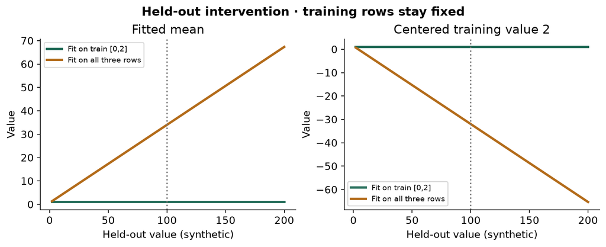

Synthetic held-out intervention; the training-only estimate stays fixed.

### Task 1 · Fit the information boundary

**Goal:** implement median imputation followed by standardization using only `train` indices. **Why:** a split does not protect you if preprocessing fitted on held-out rows already. **Hint boundary:** compute median, fill missing values, then compute training mean and population SD; use scale 1 for constants. Return transformed float32 data and JSON-compatible fit parameters. Predict the held-out intervention CHECK before running it.

```python
# TODO 1 — complete the training-only fit.
def prepare_numeric(x, train):
    x=np.asarray(x,dtype=float)
    median = ____
    if not np.isfinite(median).all():
        raise ValueError('Entirely missing training feature.')
    filled=np.where(np.isnan(x),median,x)
    mean,scale = ____, ____
    scale=np.where(scale==0,1,scale)
    return ____, {'median':median.tolist(),'mean':mean.tolist(),'scale':scale.tolist()}
```

```python
# CHECK 1 — change held-out rows, retain the same training transformation.
x=np.array([[0.,5.],[2.,5.],[np.nan,7.],[100.,9.]])
z,state=prepare_numeric(x,np.array([0,1]))
x[2:]=10000
z2,state2=prepare_numeric(x,np.array([0,1]))
assert state==state2, 'Held-out rows changed fitted parameters.'
assert np.allclose(z[:2,0],[-1,1]) and np.array_equal(z[:2],z2[:2])
assert np.isfinite(z).all() and np.array_equal(z[:2,1],[0,0]), 'Constant/missing feature policy failed.'
print('CHECK 1 passed: held-out intervention cannot affect training preprocessing.')
```

## 3. Model architecture — audit the FT-T variant

The outer information boundary is now fixed. Within it, audit the actual FT-T contestant: feature tokenization, residual blocks and the CLS readout. This prevents a familiar model name from concealing a materially different implementation.

This is a review of FT-Transformer, with a more faithful numeric path than L046’s GELU teaching variant. A scalar xⱼ becomes a learned vector xⱼwⱼ+bⱼ, where wⱼ and bⱼ each have d coordinates. Stack C vectors and prepend the learned classification token, **CLS**, to obtain [B,C+1,d]. CLS begins independent of the input and collects row information through attention.

**In plain terms.** Attention lets each token ask every other token in the same row a question and blend in the answers. A **residual connection** then adds that blended update back onto the token's original value, so the update refines the token rather than replacing it.

Within a head, learned query, key and value maps produce Q, K and V. The weight matrix is softmax(QKᵀ/√dₕ), where dₕ=d/heads. Softmax exponentiates and normalizes each receiver’s scores across senders. Multiplying by V forms weighted sums. Concatenate heads, project back to width d, and add the incoming tokens: this addition is the residual connection. Attention weight dropout is 0.1 during training; evaluation disables it.

Next comes a featurewise feed-forward update. **Layer normalization** rescales coordinates within a token and learns a scale and offset. A linear map produces 2h coordinates, split into a and b; **ReGLU** returns a⊙max(b,0), with h=floor(4d/3). The symbol ⊙ denotes coordinatewise multiplication. For a=[2,−1] and b=[3,−4], the result is [6,0]. Dropout 0.1 and a second linear map return to d coordinates; add the residual. Skip the first attention normalization, but retain later attention normalizations and every FFN normalization. [Paper Appendix E](https://arxiv.org/html/2106.11959v5#A5).

After the blocks, select CLS: [B,d]. LayerNorm → ReLU → linear d→1 gives one **logit**, an unrestricted score per row. Sigmoid converts it into a probability; binary cross-entropy trains directly from logits. XGBoost instead adds decision trees to improve a loss; its tree count and depth play different roles from neural epochs and width. The MLP is two linear/ReLU/dropout hidden layers of width 64 followed by one logit.

The paper fixes eight heads; this learning variant uses four. Its two blocks and width 32 also differ from the paper’s tuned configurations. The copied-weight check compares our complete numeric path to `rtdl_revisiting_models 0.0.2` in double precision, including input gradients. We retain all queries in the last layer; the reference computes only the final CLS query, which yields the same readout in the checked evaluation path. This is model-function evidence, not full training parity. It does not validate categorical embeddings, stochastic dropout alignment, the original training environment or benchmark results. [Reference implementation](https://github.com/yandex-research/rtdl-revisiting-models).

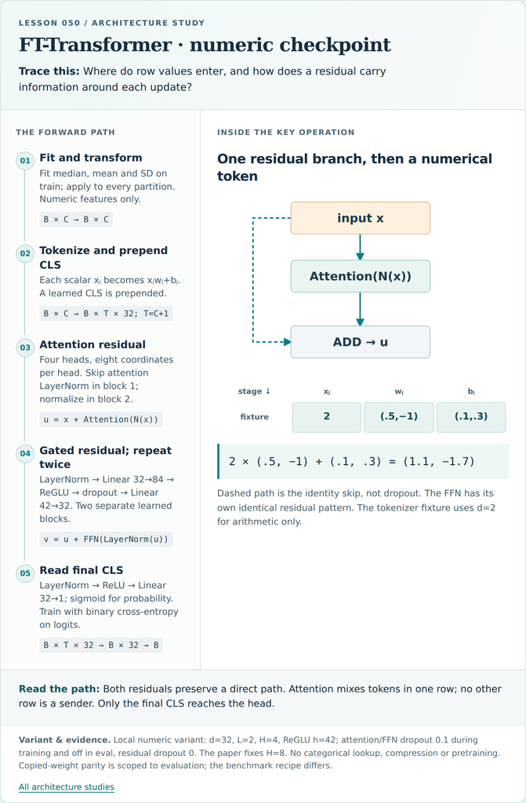

*Portable architecture figure. On a narrow notebook screen, scroll horizontally to retain readable labels.* [Open the responsive diagram](https://avistian.github.io/relational/labs/html/architecture-review/0050-ftt.html).

**Read the path:** Both residuals preserve a direct path. Attention mixes tokens in one row; no other row is a sender. Only the final CLS reaches the head.

**Variant and evidence:** Local numeric variant: d=32, L=2, H=4, ReGLU h=42; attention/FFN dropout 0.1 during training and off in eval, residual dropout 0. The paper fixes H=8. No categorical lookup, compression or pretraining. Copied-weight parity is scoped to evaluation; the benchmark recipe differs.

### Follow a value through a residual block

The architecture figure's scalar 2 becomes the two-coordinate token (1.1,−1.7) under the illustrative weights (0.5,−1) and bias (0.1,0.3). Different columns have different learned vectors: the number 2 in “age” need not receive the same representation as 2 in “balance.” Token identity is learned through these column-specific parameters; there is no temporal ordering of tokens implied by column order.

For a separate projected-attention fixture, hold a receiver's two sender scores at (0, ln 3) and value coordinates at (2,6). Softmax produces (1/4,3/4), so this output coordinate is 1/4×2 + 3/4×6 = 5. If that coordinate enters the residual at 1, the residual result is 6, assuming identity output projection for this illustration. Attention supplies an update; it does not replace the incoming representation. Actual learned Q/K/V and output projections couple coordinates, and actual attention includes every feature token plus CLS. The fixture isolates the weighted sum, not an entire trained model.

The FFN then applies another update separately to each token. With width d=32, hidden width h=floor(4d/3)=42: the first linear map emits 84 numbers, ReGLU reduces them to 42, and the second map returns 32. The split is essential: a 32→42→32 ReLU network is not the same parameterization. The FFN does not directly communicate between tokens; the preceding attention provides that communication. Its parameters are shared across token positions within a block, while different blocks own separate parameters.

Why can the reference compute only the last CLS query? At that final attention step, each output receiver reads keys and values from the incoming tokens. Computing another receiver's output cannot alter the CLS output in the same step. The remaining normalization, FFN and head operate tokenwise, and only CLS is read. Earlier blocks must still update feature tokens, because later attention needs their updated keys and values. Dropping all non-CLS queries in every block would therefore change the model.

### Know what the parity check leaves open

Copied-weight evaluation asks whether two implementations calculate the same function at the tested inputs. It deliberately removes initialization differences and turns off dropout. Training also depends on initialization, minibatch order, dropout masks, optimizer state, precision and checkpoint selection. Retaining all final-layer queries changes the shape of dropout draws during training; exact seeded training trajectories need not match the reference even though the checked evaluation function agrees.

In evaluation, the first row's output must remain fixed when other batch rows change. The lab now verifies this directly. This is a stronger test of the pictured information boundary than merely observing an output of shape [B]. It does not prove all possible inputs or variants correct: the source check covers one numeric configuration and the training recipe remains separately audited.

### Task 2 · Reconstruct the gated update

**Goal:** implement ReGLU from its two equal halves. **Why:** L046 used GELU; preserving a model name while changing its activation does not establish exact model fidelity. **Hint boundary:** gate the first half with the rectified second half; preserve all leading dimensions. The CHECK examines gradients as well as values.

```python
# TODO 2 — Appendix E feed-forward activation.
def reglu(x):
    a,b = ____
    return ____
```

```python
# CHECK 2 — values and derivatives distinguish the two halves.
x=torch.tensor([[2.,-1.,3.,-4.]],requires_grad=True)
y=reglu(x)
assert torch.equal(y,torch.tensor([[6.,0.]])), 'Use a * ReLU(b), not ReLU(a) * b.'
y.sum().backward()
assert torch.equal(x.grad,torch.tensor([[3.,0.,2.,0.]])), 'The closed gate must block both routes.'
print('CHECK 2 passed.')
```

```python
# PROVIDED — §3.3 attention, explicit Q/K/V and weighted sums
class CheckpointAttention(nn.Module):
    """§3.3: independent Q/K/V maps, scaled scores, weighted values, projection."""
    def __init__(self, d, heads, dropout):
        super().__init__()
        self.heads = heads
        self.q, self.k, self.v, self.out = [nn.Linear(d, d) for _ in range(4)]
        self.drop = nn.Dropout(dropout)
        for layer in (self.q, self.k, self.v, self.out):
            nn.init.zeros_(layer.bias)

    def forward(self, x):
        b, c, d = x.shape
        def split(layer):
            return layer(x).reshape(b, c, self.heads, d//self.heads).transpose(1, 2)
        q, k, v = split(self.q), split(self.k), split(self.v)
        weights = torch.softmax(q @ k.transpose(-1, -2) / (d//self.heads)**.5, -1)
        mixed = (self.drop(weights) @ v).transpose(1, 2).reshape(b, c, d)
        return self.out(mixed)
```

```python
# PROVIDED — Appendix E: residual wiring and your live ReGLU
class CheckpointBlock(nn.Module):
    """First attention has no LayerNorm; FFN always has pre-normalization."""
    def __init__(self, d, heads, first, attention_dropout, ffn_dropout):
        super().__init__()
        self.norm1 = nn.Identity() if first else nn.LayerNorm(d)
        self.attention = CheckpointAttention(d, heads, attention_dropout)
        self.norm2 = nn.LayerNorm(d)
        hidden = int(d * 4/3)
        self.linear1, self.linear2 = nn.Linear(d, 2*hidden), nn.Linear(hidden, d)
        self.drop = nn.Dropout(ffn_dropout)

    def forward(self, x):
        x = x + self.attention(self.norm1(x))
        return x + self.linear2(self.drop(reglu(self.linear1(self.norm2(x)))))
```

```python
# PROVIDED — complete numeric model and simple neural baseline
class CheckpointFT(nn.Module):
    """Full numeric prediction path; residual dropout fixed at zero."""
    def __init__(self, features, d=32, layers=2, heads=4, attention_dropout=.1, ffn_dropout=.1):
        super().__init__()
        self.weight = nn.Parameter(torch.empty(features, d))
        self.bias = nn.Parameter(torch.empty(features, d))
        self.cls = nn.Parameter(torch.empty(d))
        for p in (self.weight, self.bias, self.cls):
            nn.init.uniform_(p, -d**-.5, d**-.5)
        self.blocks = nn.ModuleList([CheckpointBlock(d, heads, i == 0, attention_dropout, ffn_dropout) for i in range(layers)])
        self.norm, self.head = nn.LayerNorm(d), nn.Linear(d, 1)

    def forward(self, x):
        tokens = x.unsqueeze(-1) * self.weight + self.bias
        tokens = torch.cat([self.cls.expand(len(x), 1, -1), tokens], 1)
        for block in self.blocks:
            tokens = block(tokens)
        return self.head(F.relu(self.norm(tokens[:, 0]))).squeeze(-1)


class CheckpointMLP(nn.Module):
    """§3.1 baseline: two linear/ReLU/dropout layers and one binary head."""
    def __init__(self, features, d=64):
        super().__init__()
        self.net = nn.Sequential(nn.Linear(features,d), nn.ReLU(), nn.Dropout(.1),
                                 nn.Linear(d,d), nn.ReLU(), nn.Dropout(.1), nn.Linear(d,1))
    def forward(self, x):
        return self.net(x).squeeze(-1)
```

```python
# PROVIDED — copied-weight validation against the installed reference, not a library training arm
def reference_parity():
    """Copy reference weights; check logits and input gradients (eval, numeric path)."""
    import rtdl_revisiting_models as rtdl
    torch.manual_seed(50)
    reference = rtdl.FTTransformer(n_cont_features=4,cat_cardinalities=[],d_out=1,
        n_blocks=2,d_block=16,attention_n_heads=4,attention_dropout=.1,
        ffn_d_hidden_multiplier=4/3,ffn_dropout=.1,residual_dropout=0.).double().eval()
    own = CheckpointFT(4,d=16,layers=2,heads=4).double().eval()
    def cp(a,b): a.data.copy_(b.data)
    cp(own.weight,reference.cont_embeddings.weight); cp(own.bias,reference.cont_embeddings.bias)
    cp(own.cls,reference.cls_embedding.weight)
    for i,(a,b) in enumerate(zip(own.blocks,reference.backbone.blocks)):
        for local, remote in [('q','W_q'),('k','W_k'),('v','W_v'),('out','W_out')]:
            getattr(a.attention,local).load_state_dict(getattr(b['attention'],remote).state_dict())
        if i: a.norm1.load_state_dict(b['attention_normalization'].state_dict())
        a.norm2.load_state_dict(b['ffn_normalization'].state_dict())
        a.linear1.load_state_dict(b['ffn'].linear1.state_dict())
        a.linear2.load_state_dict(b['ffn'].linear2.state_dict())
    own.norm.load_state_dict(reference.backbone.output.normalization.state_dict())
    own.head.load_state_dict(reference.backbone.output.linear.state_dict())
    x = torch.randn(7,4,dtype=torch.double,requires_grad=True)
    xr = x.detach().clone().requires_grad_()
    a,b = own(x), reference(xr,None).squeeze(-1)
    a.sum().backward(); b.sum().backward()
    forward, gradient = (a-b).abs().max().item(), (x.grad-xr.grad).abs().max().item()
    assert forward < 1e-10 and gradient < 1e-10, (forward,gradient)
    return {'max_logit_error':forward,'max_input_gradient_error':gradient,
            'reference_version':importlib.metadata.version('rtdl_revisiting_models'),
            'reference_sha256':hashlib.sha256(Path(inspect.getfile(rtdl)).read_bytes()).hexdigest(),
            'scope':'numeric, 2 blocks, 4 heads, no compression, eval; not optimizer/dropout parity'}
```

```python
# CHECK — the reference is a validator; your model is the measured implementation.
parity=reference_parity()
print(parity)
original_reglu=reglu
calls=[]
def counted_reglu(x):
    calls.append(tuple(x.shape));return original_reglu(x)
reglu=counted_reglu
probe=CheckpointFT(4,d=16,layers=2,heads=4)
probe(torch.randn(3,4)).sum().backward()
reglu=original_reglu
assert len(calls)==2,'The visible model bypassed your ReGLU.'
print('CHECK: the student activation lies on the forward/backward path.')
```

### Trace the visible blocks

`CheckpointAttention` reshapes [B,T,d] into [B,H,T,d/H], normalizes each receiver over sender tokens, merges heads, then projects. `CheckpointBlock` adds two residual branches; its first attention normalization is identity. `CheckpointFT` tokenizes each scalar and reads only CLS after two blocks. `CheckpointMLP` has no token axis: it maps the whole row through two hidden layers.

**Predict and test:** in evaluation mode, replacing other rows in a batch must not change the first row's prediction. A batch-dependence failure would contradict this FT-T variant's information boundary. This invariant does not apply automatically to SAINT intersample attention.

```python
# CHECK — no cross-row information access in FT-T evaluation.
probe.eval()
rows=torch.randn(5,4)
with torch.no_grad():
    first=probe(rows)[0]
    intervened=rows.clone();intervened[1:]*=100
    assert torch.allclose(first,probe(intervened)[0],atol=1e-6)
    assert torch.allclose(first,probe(rows[:1])[0],atol=1e-6)
print('CHECK: other batch rows cannot affect the held-fixed row in eval.')
```

## 4. Let validation select; let test evaluate

Knowing the forward path tells us what each candidate computes. It does not tell us which candidate to deploy. Validation makes that choice; test must evaluate the already chosen procedure rather than participate in choosing it.

**In plain terms.** The validation set is allowed to pick the winner among candidates; the test set is only allowed to score the winner once it is chosen. The moment you let the test score influence which candidate you keep, you have quietly turned the test set into a second validation set and the score stops being trustworthy.

A **hyperparameter** is a configuration chosen outside weight optimization. Each model family receives exactly two declared candidates per training seed. FT-T and MLP try learning rates 0.001 and 0.0003. XGBoost tries maximum depths 3 and 6 at learning rate 0.05. This is a small fixed search, not comprehensive tuning. Reusing seeds 0,1,2 pairs each family’s run by index; it does not make their random operations equivalent.

Neural candidates train at most 35 epochs, in batches up to 256 rows, with AdamW. An **epoch** visits the training rows once. Restore the checkpoint with highest validation AUROC; stop after eight epochs without improvement. XGBoost trains at most 160 trees and stops after 20 rounds without validation improvement; its sklearn prediction interface uses the selected best iteration. Exact validation ties choose the earlier checkpoint or first candidate. See [XGBoost early-stopping documentation](https://xgboost.readthedocs.io/en/stable/python/python_intro.html#early-stopping).

**AUROC** measures how well scores rank positives above negatives across thresholds. A random ordering has expected AUROC 0.5; 1 means perfect ranking on the evaluated rows. It does not measure calibration or fix a deployment threshold. Selection uses validation AUROC for every arm. Only after choosing the candidate do we produce that arm’s test probabilities. No rejected candidate gets a test score in the actual experiment.

**Worked example.** For synthetic candidates A and B, validation AUROC is [0.80,0.86] while test AUROC is [0.91,0.82]. Because selection uses validation, candidate B must win. Reading the test column to choose A instead would turn the test set into another validation set. **Predict:** why does the reported number rise when the procedure becomes less trustworthy?

**Equal trials do not mean equal compute.** Two transformer fits can cost more than two tree fits, and two handpicked points cover different fractions of each family’s useful search space. Record training time and distinguish “best under this candidate count” from “best within 15 minutes.” Comparing those policies would be a new experiment with its own frozen rules. The paper’s Appendix D.2 studies time budgets explicitly.

### Trace the selected candidate all the way to test

Early stopping is the same operation at a finer scale. Each epoch is a candidate checkpoint. Validation chooses one; test evaluates that choice. A model trained for 100 epochs can therefore make many adaptive uses of validation even if only one hyperparameter configuration was launched.

Ties need a declared policy too. “First maximum” and “latest maximum” are reproducible rules, but they can choose different checkpoints. Floating-point closeness is not automatically equality: adding an undocumented tolerance changes the selection procedure. Read the implemented rule and record it rather than silently substituting your preferred one.

The selection function in the lab should reject missing or nonfinite candidate scores. Treating a failed candidate as AUROC 1 would reward failure. Treating it as absent without recording that fact would hide an incomplete search. Save failures separately, then apply the selection rule only according to the stated policy.

After inspection, you may reasonably want to change the search. That is a new development round. The original test has supplied feedback and cannot simultaneously remain an untouched estimate for the revised procedure. Preserve the first result and obtain new independent evaluation evidence for the revision.

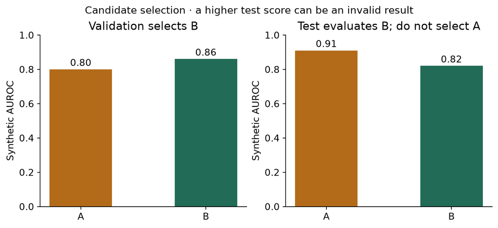

Synthetic candidates: validation picks B; choosing A from its test score invalidates the evaluation.

### Task 3 · Select without access to test

**Goal:** choose the first candidate attaining maximum finite validation AUROC. **Why:** the function signature itself should exclude test scores. **Hint boundary:** reject an empty, non-vector or non-finite input. Return an integer candidate index. The synthetic test scores in the explanation are deliberately absent from this function.

```python
# TODO 3 — validation-only selection.
def select_trial(validation_scores):
    scores=np.asarray(validation_scores)
    if scores.ndim!=1 or not len(scores) or not np.isfinite(scores).all():
        raise ValueError('Need finite validation scores.')
    return ____
```

```python
# CHECK 3 — maximum and declared tie rule.
assert select_trial([.80,.86])==1, 'Candidate B wins validation.'
assert select_trial([.86,.86])==0, 'Exact ties choose the first candidate.'
try: select_trial([.8,np.nan])
except ValueError: pass
else: raise AssertionError('Non-finite validation scores must fail.')
print('CHECK 3 passed.')
```

```python
# PROVIDED — read early stopping, best-weight restoration, loss and optimizer groups
def train_neural(model, xtrain, ytrain, xvalid, yvalid, *, seed, lr, epochs, patience=8, device='cpu'):
    """Validation-only early stopping; hold out test inputs until after selection."""
    model.to(device)
    xt, xv = [torch.as_tensor(x,device=device) for x in (xtrain,xvalid)]
    yt = torch.as_tensor(ytrain,dtype=torch.float32,device=device)
    # Follow reference exclusion: no decay on embeddings, biases or normalization.
    decay, no_decay = [], []
    for name,p in model.named_parameters():
        (no_decay if p.ndim < 2 or name in ('weight','bias','cls') else decay).append(p)
    opt = torch.optim.AdamW([{'params':decay,'weight_decay':1e-5},
                            {'params':no_decay,'weight_decay':0.}],lr=lr)
    generator = torch.Generator().manual_seed(seed)
    best, state, wait, best_epoch = -1., None, 0, 0
    history = []
    for epoch in range(epochs):
        model.train()
        for idx in torch.randperm(len(xt),generator=generator).split(256):
            idx = idx.to(device)
            opt.zero_grad()
            loss = F.binary_cross_entropy_with_logits(model(xt[idx]),yt[idx])
            loss.backward(); opt.step()
        model.eval()
        with torch.no_grad(): score = roc_auc_score(yvalid,model(xv).sigmoid().cpu().numpy())
        history.append(float(score))
        if score > best:
            best, state, wait, best_epoch = float(score), copy.deepcopy(model.state_dict()), 0, epoch+1
        else: wait += 1
        if wait >= patience: break
    model.load_state_dict(state)
    return model, {'validation_auc':best,'best_step':best_epoch,'history':history}
```

```python
# PROVIDED — batched inference; XGBoost uses its best iteration
def predict(model, x, device='cpu'):
    if isinstance(model, XGBClassifier): return model.predict_proba(x)[:,1]
    model.eval()
    with torch.no_grad():
        return np.concatenate([model(torch.as_tensor(chunk,device=device)).sigmoid().cpu().numpy()
                               for chunk in np.array_split(x,max(1,int(np.ceil(len(x)/1024))))])
```

## 5. Pair the differences; count the datasets

Once selection is frozen, compare models on the same test cases and datasets. Pairing preserves which scores belong to the same evaluation condition; choosing the correct aggregate unit keeps extra seeds from masquerading as broader evidence.

**In plain terms.** Compare scores belonging to the same declared evaluation condition, then summarize their differences. Shared variation can cancel, but identical seed numbers do not ensure that different training libraries experience the same random perturbation. The paired differences, rather than two separate error bars, show how stable the observed gap is.

For one task, let aₛ and bₛ be FT-T and XGBoost test AUROC for seed s. Calculate δₛ=aₛ−bₛ before summarizing. The paired mean δ̄ is the average of these differences. Its sample standard deviation is sδ=√[Σ(δₛ−δ̄)²/(S−1)], where S=3 is the number of training seeds. Dividing by S−1 gives sample SD, not the population SD used earlier to scale inputs.

A conventional 95% t interval for the conditional seed mean is δ̄ ± t₀.₉₇₅,S−1 sδ/√S. For three seeds the multiplier is about 4.303, which warns how little precision three runs provide. The t model assumes suitably independent, approximately normal seed differences. With S=3 that assumption cannot be assessed well. These intervals describe initialization, minibatch and stochastic fitting variability on *one fixed split and selected search procedure*. They do not include alternative test samples, new hospitals, future periods or new datasets.

**Worked example.** FT-T scores [0.80,0.82,0.84] and tree scores [0.79,0.81,0.83] give paired differences [0.01,0.01,0.01]. Each model’s scores vary across seeds, but the paired difference does not vary at all. Overlapping separate error bars would miss this structure entirely. Even so, a zero-width seed interval still says nothing about uncertainty over a new test population.

Next average each model’s seed scores *within each task*. Rank those means from best (rank 1) to worst, sharing ranks for exact ties. Average those ranks across the three tasks. A rank treats a 0.001 margin and a 0.10 margin alike, so retain actual differences beside it. Averaging ranks avoids making a high-score or large-row-count task silently dominate, but it also discards effect size.

The **Friedman test** checks whether three or more models’ ranks differ systematically across datasets. The **Nemenyi critical difference** is a threshold for differences between average ranks, CD=qα√[k(k+1)/(6N)], with k models and N datasets. Here k=N=3 and qα≈2.344, giving CD≈1.914. This small-N asymptotic procedure is a teaching diagnostic, not strong confirmatory evidence. Do not count nine seed fits as nine datasets. [Demšar (2006)](https://www.jmlr.org/papers/v7/demsar06a.html).

For the primary two-family comparison, also report the exact two-sided sign test over non-tied dataset means. Even a 3–0 sweep yields p=2×(1/2)³=0.25 under equally likely independent win directions. That makes the sample-size limitation tangible. The convenience sample also limits the population being generalized to. Neither test’s failure to reject proves equality. **Equivalence** would require a predeclared practically negligible margin and an appropriate design with sufficient precision.

### Pair first, average second

For a synthetic three-task example, suppose transformer AUROCs are (0.81, 0.85, 0.90) and tree AUROCs are (0.80, 0.90, 0.85). Transformer minus tree gives +0.01, −0.05 and +0.05: positive means the transformer is better. Pairing keeps both models exposed to the same task. It does not guarantee variance reduction when seed numbers refer to unrelated random operations in different software libraries.

Across datasets, metric scales or task difficulties may differ; even AUROC differences have different practical implications across applications. Ranking within each dataset makes the comparison ordinal: first place is 1, second is 2, and ties receive average ranks. Here the transformer's ranks are 1, 2, 1, with mean 4/3. This describes frequency of relative position, while discarding whether a win was large or tiny. Keep per-dataset effect sizes beside ranks so the summary cannot hide that distinction.

A paired dataset bootstrap draws dataset indices with replacement and carries all model scores for each selected dataset together. If it selects datasets [2,2,0], both models use those same indices. Resampling each model independently destroys the pairing and estimates a different uncertainty distribution.

With only a few datasets, a narrow seed interval can coexist with substantial uncertainty about transfer. A Friedman test or critical-difference diagram does not manufacture more task diversity. Failure to reject an equal-performance null is also not proof of practical equivalence. Equivalence would require a meaningful tolerance and a design capable of resolving it.

For the exit report, give three separate statements: the observed difference on each task, how stable it was under the repetitions actually run, and how far you are willing to generalize. The last statement should follow from dataset coverage, not from the number of decimal places in the table.

### Task 4 · Pair before summarizing

**Goal:** return the mean difference, sample SD and conditional 95% t interval. **Why:** separate error-bar overlap is not a paired comparison. **Hint boundary:** subtract corresponding seeds first; use `ddof=1` and S−1 degrees of freedom. A one-seed smoke run should return `None` for SD and interval, not fabricate uncertainty.

```python
# TODO 4 — paired conditional uncertainty.
def paired_summary(a,b):
    delta = ____
    if len(delta)<2:
        return {'mean':float(delta.mean()),'sd':None,'ci95':None}
    mean,sd = ____, ____
    half = ____
    return {'mean':mean,'sd':sd,'ci95':[mean-half,mean+half]}
```

```python
# CHECK 4 — parallel score shifts and a nontrivial interval.
s=paired_summary([.80,.82,.84],[.79,.81,.83])
assert np.isclose(s['mean'],.01) and s['sd']<1e-12
s=paired_summary([.80,.85,.90],[.80,.80,.80])
assert np.isclose(s['sd'],.05)
assert np.allclose(s['ci95'],[.05-4.3026527299*.05/np.sqrt(3),.05+4.3026527299*.05/np.sqrt(3)])
print('CHECK 4 passed: intervals quantify training-seed variation only.')
```

### Read the whole experiment before running

The loader is reusable infrastructure. The loop below creates your visible `CheckpointFT`, calls your preprocessing and selector, and computes test probabilities only after candidate selection. `model_factory`, `prepare` and `selector` can be inspected at the call boundary. Two candidates × three seeds × three arms × three tasks = 54 fitted candidates. A seed's checkpoint/candidate selection both use validation; this is a low-budget protocol, not nested cross-validation.

```python
# PROVIDED — complete selection-and-test loop; uses the functions you just wrote
def run_comparison(*, datasets=('diabetes','blood_transfusion','phoneme'), seeds=(0,1,2),
                   epochs=35, trees=160, d=32, layers=2, cap=None, device='cpu',
                   model_factory=CheckpointFT, prepare=prepare_numeric, selector=select_trial):
    """Two predeclared candidates per arm/seed; all use validation AUROC.

    Dataset loading/splitting is harness code; model_factory/prepare/selector keep
    the notebook's visible model and student functions on the measured path.
    """
    torch.set_num_threads(1)
    models = ['FT-Transformer','XGBoost','MLP']
    result = {'datasets':{},'models':models,'seeds':list(seeds),'split_seed':50,
              'settings':dict(epochs=epochs,trees=trees,d=d,layers=layers,cap=cap,device=device,
                              trials=2,neural_lrs=[.001,.0003],xgb_depths=[3,6],
                              xgb_lr=.05,xgb_subsample=.8,xgb_colsample=.8,patience_neural=8,patience_xgb=20),
              'scope':'local fixed split and two-candidate search; INCOMPARABLE to paper tables'}
    start = time.perf_counter()
    for name in datasets:
        frame,y = load_tier_a(name); y = np.asarray(y,dtype=int)
        assert set(np.unique(y)) == {0,1}, 'This checkpoint requires binary 0/1 labels.'
        if any(str(t) in ('category','object') for t in frame.dtypes):
            raise ValueError('Numeric-only track; categorical encoding is outside this preset.')
        raw = frame.to_numpy(dtype=float)
        source_rows = np.arange(len(y))
        if cap and len(y)>cap:
            # Label-independent subsample; exact original row IDs saved.
            source_rows = np.sort(np.random.default_rng(50).choice(len(y),cap,replace=False))
            raw,y = raw[source_rows],y[source_rows]
        tr,te = train_test_split(np.arange(len(y)),test_size=.2,stratify=y,random_state=50)
        tr,va = train_test_split(tr,test_size=.25,stratify=y[tr],random_state=50)
        x,prep = prepare(raw,tr)
        row = {'openml_id':SPECS[name]['openml_id'], 'n':len(y),'features':frame.columns.tolist(),
               'source_sha256':hashlib.sha256((CACHE/f'{name}.parquet').read_bytes()).hexdigest(),
               'source_rows':source_rows.tolist(),'split':{'train':tr.tolist(),'valid':va.tolist(),'test':te.tolist()},
               'preprocessing':prep,'y_test':y[te].tolist(),'runs':{m:[] for m in models}}
        for seed in seeds:
            for arm in models:
                candidates,logs = [],[]
                for trial in range(2):
                    torch.manual_seed(seed)
                    tick = time.perf_counter()
                    if arm == 'XGBoost':
                        model = XGBClassifier(n_estimators=trees,max_depth=[3,6][trial],learning_rate=.05,
                            subsample=.8,colsample_bytree=.8,reg_lambda=1.,tree_method='hist',n_jobs=1,
                            eval_metric='auc',early_stopping_rounds=20,random_state=seed)
                        model.fit(x[tr],y[tr],eval_set=[(x[va],y[va])],verbose=False)
                        log = {'validation_auc':float(model.best_score),'best_step':model.best_iteration+1,
                               'history':model.evals_result()['validation_0']['auc']}
                    else:
                        model = model_factory(x.shape[1],d=d,layers=layers,heads=4) if arm == 'FT-Transformer' else CheckpointMLP(x.shape[1],d=64)
                        model,log = train_neural(model,x[tr],y[tr],x[va],y[va],seed=seed,
                            lr=[.001,.0003][trial],epochs=epochs,device=device)
                    log.update(trial=trial,elapsed_s=time.perf_counter()-tick)
                    candidates.append(model); logs.append(log)
                chosen = selector([a['validation_auc'] for a in logs])
                # The first and only test access for this arm/seed, AFTER selection.
                p = predict(candidates[chosen],x[te],device)
                record = {'seed':seed,'selected_trial':chosen,'trials':logs,'probability':p.tolist(),
                          'auc':float(roc_auc_score(y[te],p)), 'accuracy':float(accuracy_score(y[te],p>=.5))}
                row['runs'][arm].append(record)
                print(name,seed,arm,round(record['auc'],5),'candidate',chosen,flush=True)
        row['summary'] = {m:paired_summary([r['auc'] for r in row['runs'][m]],np.zeros(len(seeds))) for m in models}
        row['ft_minus_xgb'] = paired_summary([r['auc'] for r in row['runs'][models[0]]],
                                             [r['auc'] for r in row['runs'][models[1]]])
        result['datasets'][name] = row
    score = np.array([[ row['summary'][m]['mean'] for m in models] for row in result['datasets'].values()])
    ranks = np.array([rankdata(-r,method='average') for r in score])
    result['mean_ranks'] = dict(zip(models,ranks.mean(0).tolist()))
    if len(score)>1:
        stat,p = friedmanchisquare(*score.T)
        wins = int(np.sum(score[:,0]>score[:,1])); losses = int(np.sum(score[:,0]<score[:,1]))
        result['statistics'] = {'friedman_chi2':float(stat) if np.isfinite(stat) else None,
            'friedman_p':float(p) if np.isfinite(p) else None,
            'nemenyi_cd':float(studentized_range.ppf(.95,3,np.inf)/np.sqrt(2)*np.sqrt(3*4/(6*len(score)))),
            'exact_sign_p':float(binomtest(wins,wins+losses,.5).pvalue) if wins+losses else 1.,
            'ft_wins':wins,'ft_losses':losses,'independent_units':len(score)}
    result['elapsed_s'] = time.perf_counter()-start
    result['versions'] = {p:importlib.metadata.version(p) for p in ('torch','numpy','scipy','scikit-learn','xgboost')}
    result['source_sha256'] = hashlib.sha256(Path(__file__).read_bytes()).hexdigest()
    return result
```

### Predict first

Write which task you expect to show the largest tree/neural difference, and why. Distinguish that conjecture from a source-backed paper claim. Do not change candidate lists after seeing the following author-reference results.

## 6. Read the author’s measured evidence

**Held fixed:** dataset rows, split IDs, transformed inputs, selection metric, two candidate counts and seed IDs. **Varied:** model family and its declared candidate settings. **Measured:** selected models’ test AUROC, per-seed differences, ranks and fit time. The purpose is to compare specified procedures, not isolate attention as a causal mechanism.

| Task | FT-Transformer | XGBoost | MLP |
| --- | --- | --- | --- |
| diabetes | 0.7924 ± 0.0094 | 0.7909 ± 0.0075 | 0.7912 ± 0.0102 |
| blood_transfusion | 0.8128 ± 0.0028 | 0.7811 ± 0.0244 | 0.8095 ± 0.0022 |
| phoneme | 0.9348 ± 0.0023 | 0.9436 ± 0.0007 | 0.9047 ± 0.0019 |

FT-T leads on 2/3 tasks. Mean ranks: FT-Transformer 1.333, XGBoost 2.333, MLP 2.333. Friedman χ²=2.000, p=0.368; Nemenyi CD=1.914. Exact two-sided sign-test p=1.000. The rank test detects no overall difference; equivalence is not established.

FT-T minus XGBoost mean AUROC and conditional 95% t intervals: diabetes: +0.0015 [-0.0384, +0.0415]; blood_transfusion: +0.0317 [-0.0345, +0.0980]; phoneme: -0.0087 [-0.0147, -0.0028]. On phoneme the seed interval lies below zero; this remains conditional on the chosen split and search. Other intervals include zero.

The author run took 91.1 seconds on CPU with numerical thread limits. Training time excludes lesson work. The copied-weight logit and input-gradient maximum errors were both 0.0e+00 in the specified reference check.

Use the table to distinguish a task-level difference from an across-task trend. Read each interval’s scope before using it as evidence. Even a consistently lower local score cannot refute a tuned ensemble result on another suite. Conversely, a published result cannot rescue a model that fails your deployment-specific comparison.

Full audit artifact includes data hashes, original row IDs, splits, preprocessing parameters, all validation histories, candidate choices, test labels/probabilities, precise scores, software versions and model-source hash. You can recompute AUROC from saved predictions and verify that every chosen candidate maximized validation performance.

### Three levels of aggregation answer three different questions

First, average **seed scores within a task** to describe the selected training procedure over the random seeds you ran. Second, rank those means **within each task**, then average ranks across tasks. Third, to deploy an **ensemble**, average the selected models' probabilities for each test row, then calculate the metric once. That third operation changes the predictor. It cannot be recovered from a table of scores alone.

Use a four-row synthetic example with labels (0,0,1,1). Model A predicts (0.9,0.8,0.7,0.1): neither positive outranks either negative, so AUROC=0. Model B predicts (0.1,0.2,0.8,0.9): all four positive-negative pairs are correct, so AUROC=1. The mean of these two scores is 0.5. Averaging their probabilities produces (0.5,0.5,0.75,0.5). One positive beats both negatives; the other ties both. Counting each tie as half a win gives (2+0.5+0.5)/4=0.75. Ensembling need not improve every dataset; this fixture demonstrates why the operations differ.

The lab adds this operation using your already selected models. It is labeled a post-hoc diagnostic because the historical test results were already available when this audit added the exercise. No ensemble weights or members are chosen using test outcomes. There is only one three-model ensemble per family and task, so you cannot report its uncertainty by reusing the SD of the three single-model scores. A future confirmatory ensemble comparison requires a frozen aggregation rule and fresh evaluation evidence.

### Interpret the baseline before explaining the winner

On blood transfusion, both neural procedures are near 0.81 while this XGBoost procedure is near 0.78. That pattern does not single out attention: the MLP is also competitive. On phoneme, FT-T improves over this MLP while the tree remains ahead. Both observations are compatible with several explanations, including representation and tuning sensitivity. A causal claim about attention needs a controlled architectural intervention with a comparable training and selection budget.

The quarter's mechanisms imply different information access. An MLP mixes a row's coordinates through fixed learned matrices. FT-T lets that row's tokens compute input-dependent mixing weights. SAINT's intersample branch additionally reads other rows; DCNv2 makes products explicit. None of these local single-table comparisons establishes the benefit of joining historical entity records. For the relational mission, first freeze a strong flat-table procedure, then evaluate whether added relationships improve the same target under a point-in-time boundary.

### Choose a useful follow-up

Inspect the saved validation histories and selected candidate indices before proposing a larger search. If the best checkpoint frequently hits the training cap, the cap may be binding; if both candidates plateau early, simply adding epochs may do little. Neither observation identifies the best future hyperparameters. Declare a follow-up using validation evidence, preserve the original test result, and obtain a fresh evaluation for any revised procedure. Adding ResNet from L042 is a sensible baseline extension: the paper's baseline argument is stronger than “beats an MLP,” and the local three-arm suite does not include it.

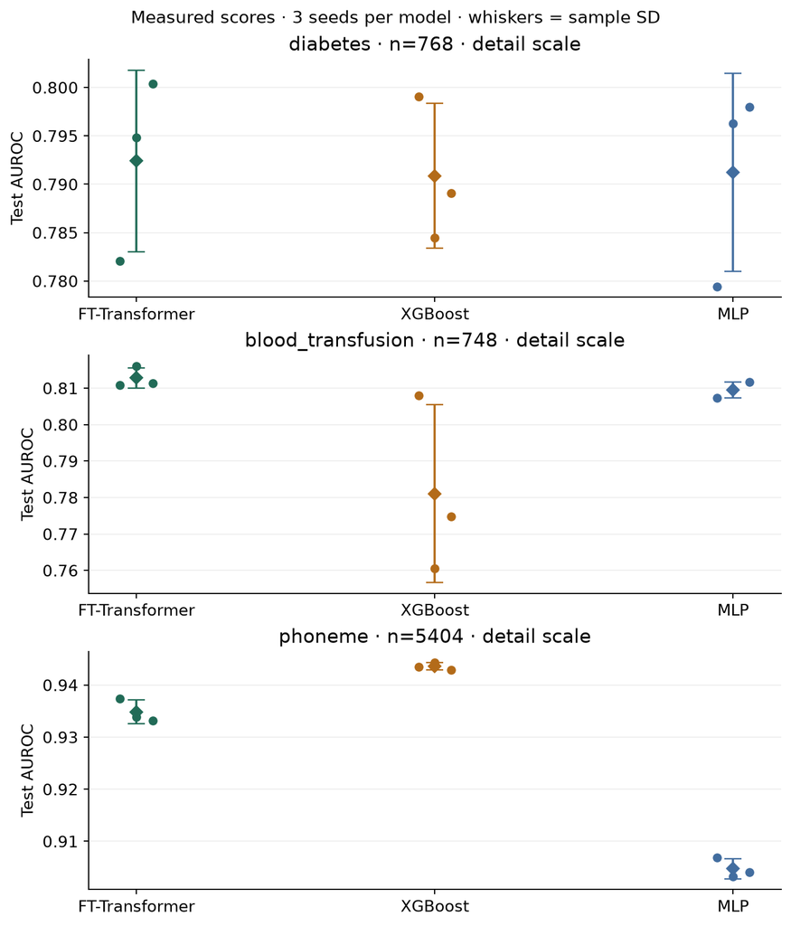

Author-reference AUROC; individual seeds and sample SD. These are saved reference measurements.

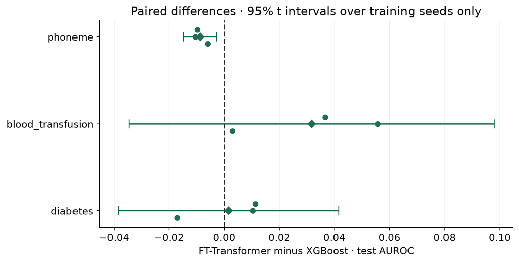

Author-reference paired differences; 95% t intervals conditional on one split.

```python
# PROVIDED — run YOUR implementation; no stored result substitutes for training.
result=run_comparison(model_factory=CheckpointFT,prepare=prepare_numeric,selector=select_trial)
rows=[]
for dataset,row in result['datasets'].items():
    for model,s in row['summary'].items():
        rows.append({'dataset':dataset,'model':model,'mean AUROC':s['mean'],'sample SD':s['sd'],'seed CI':s['ci95']})
display(pd.DataFrame(rows))
display(pd.DataFrame({name:row['ft_minus_xgb'] for name,row in result['datasets'].items()}).T)
print('Ranks:',result['mean_ranks'])
print('Dataset-level statistics:',result['statistics'])
```

```python
# CHECK — audit saved selection and recompute every test metric.
for dataset,row in result['datasets'].items():
    split=row['split'];sets=[set(split[k]) for k in ('train','valid','test')]
    assert not (sets[0]&sets[1] or sets[0]&sets[2] or sets[1]&sets[2]), 'Overlapping split rows.'
    for model,runs in row['runs'].items():
        for run in runs:
            assert run['selected_trial']==select_trial([v['validation_auc'] for v in run['trials']])
            assert np.isclose(run['auc'],roc_auc_score(row['y_test'],run['probability']))
assert result['statistics']['independent_units']==3
reference=json.loads((LABS/'_verify_l050_results.json').read_text())
max_gap=max(abs(run['auc']-reference['datasets'][d]['runs'][m][i]['auc'])
    for d,row in result['datasets'].items() for m,runs in row['runs'].items() for i,run in enumerate(runs))
print('CHECK: splits, choices and metrics audit clean. Largest author-reference gap:',max_gap)
print('Different software/hardware may change training; investigate rather than overwrite scores.')
```

### Task 5 · Score the combined predictor

**Goal:** average a [models, test rows] matrix along the model axis, then evaluate the resulting probabilities. **Why:** averaging three AUROCs answers a different question from deploying an ensemble. The paper's Table 4 combines predictions. **Hint boundary:** preserve the test-row axis; reject empty, nonfinite or out-of-range probabilities. Do not threshold or average the metric. Use all already-selected seeds with equal weights fixed in advance. The historical author results below informed this added exercise, so its result is a descriptive diagnostic, not new independent evaluation evidence.

```python
# TODO 5 — combine predictions, not metrics.
def mean_predictions(probabilities):
    p=np.asarray(probabilities,dtype=float)
    if p.ndim!=2 or not all(p.shape) or not np.isfinite(p).all() or np.any((p<0)|(p>1)):
        raise ValueError('Need a nonempty finite [models, rows] probability matrix in [0,1].')
    return ____
```

```python
# CHECK 5 — ensemble ranking is not mean single-model ranking.
y_demo=np.array([0,0,1,1])
p_demo=np.array([[.9,.8,.7,.1],[.1,.2,.8,.9]])
combined=mean_predictions(p_demo)
assert combined.shape==(4,) and np.allclose(combined,[.5,.5,.75,.5])
assert roc_auc_score(y_demo,combined)==.75
assert np.mean([roc_auc_score(y_demo,p) for p in p_demo])==.5
print('CHECK 5: mean AUROC .50, ensemble AUROC .75. Explain the changed pair ordering.')
ensemble_rows=[]
for dataset,row in result['datasets'].items():
    for model,runs in row['runs'].items():
        probabilities=mean_predictions([run['probability'] for run in runs])
        ensemble_rows.append(dict(dataset=dataset,model=model,
            mean_seed_auc=row['summary'][model]['mean'],
            ensemble_auc=float(roc_auc_score(row['y_test'],probabilities)),
            status='POST_HOC_DIAGNOSTIC; INCOMPARABLE to Table 4'))
result['diagnostic_ensembles']=ensemble_rows
display(pd.DataFrame(ensemble_rows))
```

## EXIT · defend the result

Export the score table, paired intervals, rank summary, diagnostic ensemble table and run ledger. Explain why the ensemble metric differs from the mean seed metric and why this added diagnostic does not reproduce Table 4. Write 120–180 words naming the population, metric, candidate budget, uncertainty unit, one measured finding, and at least two paper-protocol mismatches. Propose one new experiment whose settings you would freeze before viewing results. Do not equate nonsignificance with equivalence or “won two tasks” with universal superiority.

Paste these outputs and your explanation to the teacher for a 0–10 review: correctness, leakage discipline, conceptual explanation, independent implementation effort, reproduction audit. A defensible INCOMPARABLE result can earn full audit credit; an unrun next step must remain NOT_RUN.

```python
# EXIT — save evidence and identify the code objects that actually ran.
from _audit_l050 import implementation_identity
implementation_id=implementation_identity(globals())
result['visible_code_identity']=implementation_id
Path('l050-student-results.json').write_text(json.dumps(result,indent=2))
print('Saved l050-student-results.json; implementation identity',implementation_id)
# Write your claim audit in the next markdown cell.
```

**My claim audit:** *Write your 120–180 words here. This prose is reviewed by the teacher, not automatically graded.*

## 7. Required next step — move toward the paper’s result

**In plain terms.** Moving to a bigger dataset makes your local numbers look more like the paper's, but it does not make them the same experiment. Until the split, preprocessing, budget and selection all match, a close number is a coincidence, not a reproduction.

The three-task checkpoint does not use paper benchmark datasets. The separate scale-up uses **Higgs Small**, the 98,050-row, 28-feature numeric task used by Gorishniy et al. This is distinct from demanding the original multi-million-row Higgs dataset. Table 2 reports FT-T accuracy 0.729; Table 4’s ensemble comparison is a separate target. Sources: [dataset table](https://arxiv.org/html/2106.11959v5#A2.SS1) and [Table 2](https://arxiv.org/html/2106.11959v5#S4.SS4).

Our `closer` run takes 6,000 rows without consulting labels, widens FT-T to 64 coordinates and three blocks, and increases the caps to 50 epochs and 400 trees. It retains the same visible implementation and three training seeds. The `paper` resource preset uses all 98,050 rows, d=192, three blocks, 100 epochs and 2,000 trees. Its name describes scale, not protocol fidelity: it still does not reconstruct the original splits, quantile transform, search or repetition scheme.

**Measured closer attempt:** Higgs Small accuracy (mean ± sample SD): FT-Transformer 0.6831 ± 0.0039; XGBoost 0.6847 ± 0.0021; MLP 0.6483 ± 0.0055. CPU fitting took 1814 seconds. **INCOMPARABLE** to Table 2 because the split, preprocessing, budget and selection differ. The full resource preset and Table 4 ensemble suite remain NOT_RUN. Scale-up ledger.

**Recipe audit:** paper §4.3 evaluates one tuned configuration over 15 seeds and forms three ensembles of five models. Our loop reselects among two candidates separately for each of three seeds. Those seed repeats include selection variability. Appendix E.1 fixes eight attention heads; every current local/scale preset uses four. Appendix F.3 uses 50-round tree early stopping; ours uses 20. Reporting accuracy after AUROC-based selection does not repair the metric mismatch.

**Missing paper coverage:** California Housing, Adult, Helena, Jannis, ALOI, Epsilon, Year, Covertype, Yahoo and Microsoft; regression, multiclass and categorical branches; tuned ensembles and the full statistical population. A coincidentally close Higgs accuracy is not a MATCH. The supplied ±0.01 target tolerance only becomes meaningful once the protocol matches.

Run `python labs/_paper_repro_l050.py --preset closer --out labs/data/cache/l050-your-run` from the repository root, or use the notebook’s gated GPU cell. For an unattended T4 run use `modal run --detach modal/l050_paper_repro.py --preset closer`. Completed seeds resume from disk; changed source/data/configuration rejects cache reuse. Checkpoints are per completed seed, so an interrupted seed restarts. Reproduction contract · Modal operator.

### Required next step · choose compute, preserve the claim boundary

The same visible experiment runs on Higgs Small. The imported operator only handles presets, per-seed persistence and the conclusion ledger; your visible trainer and model remain in `run_comparison`. The gate is off by default. For Colab, select a GPU runtime before enabling it. Completion of the larger experiment is distinct from passing the local implementation CHECKs.

The fingerprint below distinguishes your code from the canonical operator's cache. Choose a new output folder when the code, environment or data changes. The `paper` preset remains an incomplete protocol reconstruction and must not be called MATCH.

```python
# PROVIDED — larger-run gate; no cloud job launches automatically.
from _paper_repro_l050 import run as scaleup_operator, TARGET
from relkit.paper_repro import format_ledger, LabFinding
RUN_PAPER_REPRO=False
PAPER_PRESET='closer'
if RUN_PAPER_REPRO:
    # Recompute here: a cell may have been edited since EXIT.
    implementation_id=implementation_identity(globals())
    def live_experiment(**kwargs):
        return run_comparison(model_factory=CheckpointFT,prepare=prepare_numeric,selector=select_trial,**kwargs)
    scaleup=scaleup_operator(PAPER_PRESET,out='data/cache/l050-student-'+implementation_id[:12],
        device='cuda' if torch.cuda.is_available() else 'cpu',experiment=live_experiment,
        implementation_id=implementation_id)
else:
    print(format_ledger(title='L050 student session',
        lab=[LabFinding('Your completed local experiment',str(result['mean_ranks']),
                        '3 numeric substitute datasets; two candidates; fixed split')],
        paper=[(TARGET,None,'NOT_RUN')]))
```